# meta-analysis of proportions

Ronil V. Chandra

18/04/2020

# Load required packages

```r
library(tidyverse)
library(meta)
library(metafor)
```

# Load required data

```r
maindata <- read_csv("data/psash-170420-test.csv")
```

# Correct vector types

```r
maindata %>%
  mutate(pub = as.integer(pub),
         start = as.integer(start),
         end = as.integer(end),
         psah = as.double(psah),
         fu = as.double(fu),
         nos_select = as.double(nos_select),
         nos_outcome = as.double(nos_outcome),
         nos_compare = as.double(nos_compare),
         nos_outcome = as.double(nos_outcome),
         country = as.factor(country),
         type = as.factor(type))
```

```
## # A tibble: 12 x 30
##    auth    pub authpub start   end country type  num_tot fem_tot fam_tot
##    <chr> <int> <chr>   <int> <int> <fct>   <fct>   <dbl>   <dbl>   <dbl>
##  1 Bor    2015 Bor 20…    NA    NA Intern… pros…     363     280      72
##  2 Bor    2015 Bor 20…    NA    NA Intern… pros…     363     280      72
##  3 Bor    2015 Bor 20…    NA    NA Intern… pros…     363     280      72
##  4 Bor    2015 Bor 20…    NA    NA Intern… pros…     363     280      72
##  5 Brod…  2009 Broder…    NA    NA Intern… pros…     113      75     113
##  6 Brod…  2009 Broder…    NA    NA Intern… pros…     113      75     113
##  7 Brod…  2009 Broder…    NA    NA Intern… pros…     113      75     113
##  8 Brod…  2009 Broder…    NA    NA Intern… pros…     113      75     113
##  9 Burns  2009 Burns …  1987  2006 United… retr…     165     120      20
## 10 Burns  2009 Burns …  1987  2006 United… retr…     165     120      20
## 11 Burns  2009 Burns …  1987  2006 United… retr…     165     120      20
## 12 Burns  2009 Burns …  1987  2006 United… retr…     165     120      20
## # … with 20 more variables: multi_tot <dbl>, age_mean <dbl>, age_med <lgl>,
## #   num_anr_tot <dbl>, psah_tot <dbl>, smoke_tot <dbl>, fu_mean_tot <dbl>,
## #   fu_med_tot <dbl>, size <dbl>, num <dbl>, num_anr <dbl>, psah <dbl>,
## #   fu <dbl>, rupt <dbl>, rupt_psah <dbl>, rupt_fatal <dbl>, nos_select <dbl>,
## #   nos_compare <dbl>, nos_outcome <dbl>, nos_total <lgl>
```

# Confirm new data structure with correct vector types

```r
glimpse(maindata)
```

```
## Rows: 12
## Columns: 30
## $ auth        <chr> "Bor", "Bor", "Bor", "Bor", "Broderick", "Broderick", "Br…
## $ pub         <dbl> 2015, 2015, 2015, 2015, 2009, 2009, 2009, 2009, 2009, 200…
## $ authpub     <chr> "Bor 2015", "Bor 2015", "Bor 2015", "Bor 2015", "Broderic…
## $ start       <dbl> NA, NA, NA, NA, NA, NA, NA, NA, 1987, 1987, 1987, 1987
## $ end         <dbl> NA, NA, NA, NA, NA, NA, NA, NA, 2006, 2006, 2006, 2006
## $ country     <chr> "International", "International", "International", "Inter…
## $ type        <chr> "prospective", "prospective", "prospective", "prospective…
## $ num_tot     <dbl> 363, 363, 363, 363, 113, 113, 113, 113, 165, 165, 165, 165
## $ fem_tot     <dbl> 280, 280, 280, 280, 75, 75, 75, 75, 120, 120, 120, 120
## $ fam_tot     <dbl> 72, 72, 72, 72, 113, 113, 113, 113, 20, 20, 20, 20
## $ multi_tot   <dbl> 163, 163, 163, 163, NA, NA, NA, NA, 46, 46, 46, 46
## $ age_mean    <dbl> 55.0, 55.0, 55.0, 55.0, 51.4, 51.4, 51.4, 51.4, 64.0, 64.…
## $ age_med     <lgl> NA, NA, NA, NA, NA, NA, NA, NA, NA, NA, NA, NA
```

[output cut: 17 more lines]

```r
view(maindata)
```

# Analyse 10 mm or less aneurysms

```r
tendata <- filter(maindata, size == 10) %>%
view()
```

If number of aneurysms is unkown, then assume that 1 patient has 1 aneurysm ie variable num carries forward to num_anr

```r
dat <- tendata %>%
  mutate(total_10 = coalesce(num_anr,num)) %>%
  drop_na(total_10) %>%
  select(1:21, total_10, everything())
view(dat)
```

## calculate individual and pooled study proportions without transformation

xi = cases ie number of ruptures during all follow up ni = total ie number of aneurysms at study entry yi = individual effect size ie individual proportion in this study vi = sampling variances

ies = object that holds results of individual effect sizes and corresponding sampling variances

escalc() is a metafor function to estimate individual effect sizes and sampling variances

rma() is a metafor function to fit a random-effects model. This is utilised to take both intra-study and inter-study variances, to increase generalisability. This is because these samples are drawn from different populations, with different comorbidities that may influence outcome, and undergo observation in different conditions. This leads to variation in the outcomes due to random samping error.

pes = object that holds results of pooled effect size and pooled sampling variances. Note that the pooled effect size is the weighted average of the observed effect sizes in the individual studies that are weighted by the inverse of the total variance in that study.

```r
ies=escalc(xi=rupt, ni=total_10, data=dat, measure = "PR")
pes=rma(yi, vi, data=ies)
print(pes)
```

```
##
## Random-Effects Model (k = 3; tau^2 estimator: REML)
##
## tau^2 (estimated amount of total heterogeneity): 0 (SE = 0.0000)
## tau (square root of estimated tau^2 value):      0
## I^2 (total heterogeneity / total variability):   0.00%
## H^2 (total variability / sampling variability):  1.00
##
## Test for Heterogeneity:
## Q(df = 2) = 0.8093, p-val = 0.6672
##
## Model Results:
##
## estimate      se    zval    pval   ci.lb   ci.ub
##   0.0076  0.0033  2.2928  0.0219  0.0011  0.0141  *
##
## ---
## Signif. codes:  0 '***' 0.001 '**' 0.01 '*' 0.05 '.' 0.1 ' ' 1
```

This is not recommended because of the skewed distribution of the observed proportions.

Thus we need to transform the data using either the logit or double arcine methods to make it follow a normal distribution and thus enhance the validity of statistical analysis. We can change this using the measure = argument.

## calculate individual and pooled study proportions with logit transformation

this converts the observed proportion into the natural log of the proportions. Once transformed, they are more likely to follow a normal distribution, and statistical analysis can be performed. After analysis, the logits are converted back to poportions for reporting.

```r
ies.logit=escalc(xi=rupt, ni=total_10, data=dat, measure = "PLO")
pes.logit=rma(yi, vi, data=ies.logit)
pes=predict(pes.logit, transf=transf.ilogit)
print(pes)
```

```
##
##    pred  ci.lb  ci.ub  cr.lb  cr.ub
##  0.0097 0.0043 0.0213 0.0043 0.0213
```

Note the differences in the results compared to the pooled untransformed proportion.

the logit method should not be used if the event of interest is very rare like aneurysm rupture because it fails to stabilise the variance ie very high variance if proportion is close to zero or 1.

if the proportion is 0 or 1, then variance becomes undefined and an arbitrary continuity correction of 0.5 is typically added, which can bias the results.

## calculate individual and pooled study proportions with double arcine transformation

```r
ies.da=escalc(xi=rupt, ni=total_10, data=dat, measure="PFT", add=0)
pes.da=rma(yi, vi, data=ies.da, method = "DL", level = 95)
pes=predict(pes.da, transf=transf.ipft.hm, targ=list(ni=dat$total_10))
print(pes)
```

```
##
##    pred  ci.lb  ci.ub  cr.lb  cr.ub
##  0.0077 0.0018 0.0166 0.0018 0.0166
```

The DA method proposed by Freeman-Tukey stabilises the sampling variance. This is important when conducting a meta-analysis of proportions, since the proportions generated from each study are weighted by the inverse of their sample variance to create a pooled proportion.

Note that if the proportion is 0, then a constant may be added. Ensure that there is no adjustment to observed proportions by specifying add=0

## Assess and quantify heterogeniety - both between-study variance and within-study variance

This is required to assess whether the pooled proportion provides an accurate summary of the finding of interest. If there is high heterogeneity then interpretation of the data synthesis should be taken with caution.

Heterogeniety arises from both between-study and within-study variance.

Between-study variance arises from differences in the baseline populations, participant characteristics, study designs and study environment. Intra-study variance arises from random sampling error.

The between-study variance is calculated as the statistic tau-squared, and can be estimated using different random-effects models.

Although the DerSimonian and Laird (DL) method is most popular, this under-estimates between-study variance, and produces overly narrow CIs when between-study variance is high. DL estimates of tau-squared are particularly inaccurate when number of included studies is small. The HKSJ method consistently results in more adequate error rates and better performance when the number of studies is small, and when there are unequal sample sizes.

```r
ies.da.sj=escalc(xi=rupt, ni=total_10, data=dat, measure="PFT", add=0)
pes.da.sj=rma(yi, vi, data=ies.da, method = "SJ", level = 95)
pes2=predict(pes.da.sj, transf=transf.ipft.hm, targ=list(ni=dat$total_10))
print(pes2)
```

```
##
##    pred  ci.lb  ci.ub  cr.lb  cr.ub
##  0.0081 0.0013 0.0190 0.0002 0.0229
```

This is important because the estimated amount of the between-study variance influences the weights assigned to each study and hence the overall summary effect size and the precision of the effect size.

# Calculate Higgins I2 to quantify heterogeneity (model = SJ).

This is important because if there is moderate to substantial heterogeneity, then the summary effect is of little value.

```r
print(pes.da.sj, digits = 4)
```

```
##
## Random-Effects Model (k = 3; tau^2 estimator: SJ)
##
## tau^2 (estimated amount of total heterogeneity): 0.0003 (SE = 0.0006)
## tau (square root of estimated tau^2 value):      0.0184
## I^2 (total heterogeneity / total variability):   20.83%
## H^2 (total variability / sampling variability):  1.26
##
## Test for Heterogeneity:
## Q(df = 2) = 1.2594, p-val = 0.5327
##
## Model Results:
##
## estimate      se    zval    pval   ci.lb   ci.ub
##   0.1037  0.0225  4.6174  <.0001  0.0597  0.1478  ***
##
## ---
## Signif. codes:  0 '***' 0.001 '**' 0.01 '*' 0.05 '.' 0.1 ' ' 1
```

```r
confint(pes.da.sj, digits = 2)
```

```
##
##        estimate ci.lb ci.ub
## tau^2      0.00  0.00  0.04
## tau        0.02  0.00  0.21
## I^2(%)    20.83  0.00 97.14
## H^2        1.26  1.00 34.97
```

# Create simple forest plots

A simple forest plot with DL and CP method for CIs

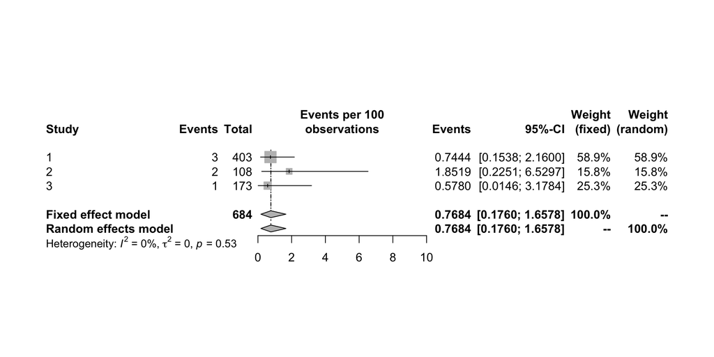

```r
pes.summary=metaprop(rupt, total_10, data=dat, sm="PFT", method.tau = "DL", method.ci = "CP")
forest(pes.summary,
       pscale = 100,
       xlim=c(0,10),
       digits = 4)
```

A simple forest plot with DL and Wilson method for CIs

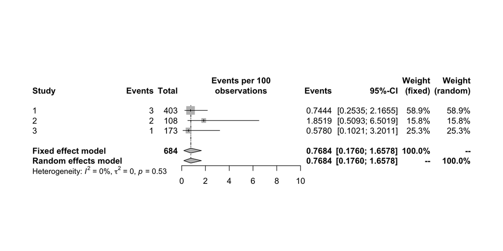

```r
pes.summary=metaprop(rupt, total_10, data=dat, sm="PFT", method.tau = "DL", method.ci = "WS")
forest(pes.summary,
       pscale = 100,
       xlim=c(0,10),
       digits = 4)
```

A simple forest plot with SJ and Wilson method for CIs

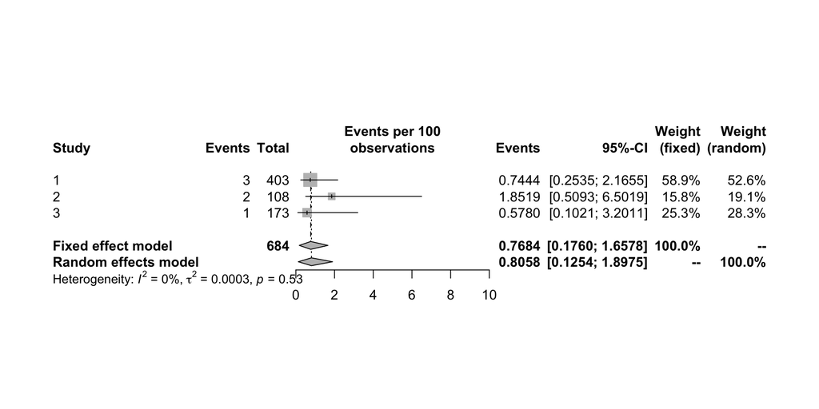

```r
pes.summary=metaprop(rupt, total_10, data=dat, sm="PFT", method.tau = "SJ", method.ci = "WS")
forest(pes.summary,
       pscale = 100,
       xlim=c(0,10),
       digits = 4)
```

# Publication quality forest plots - still working on this

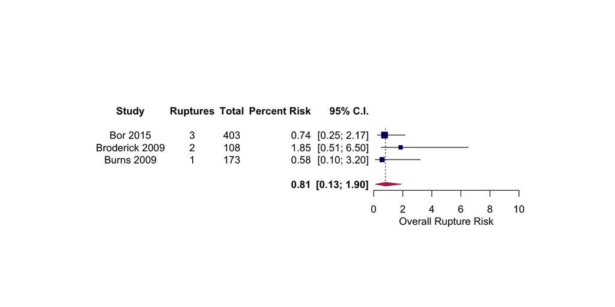

```r
pes.summary=metaprop(rupt, total_10, data=dat, sm="PFT", method.tau = "SJ", method.ci = "WS")
forest(pes.summary,
       xlim=c(0,10),
       pscale=100,
       rightcols=FALSE,
       leftcols=c("authpub", "rupt", "total_10", "effect", "ci"),
       leftlabs=c("Study", "Ruptures", "Total", "Percent Risk", "95% C.I."),
       xlab="Overall Rupture Risk", smlab="",
       weight.study="random", squaresize=0.5, col.square="navy",
       col.square.lines="navy",
       col.diamond="maroon", col.diamond.lines="maroon",
       text.random = TRUE,
       pooled.events = TRUE,
       pooled.totals = TRUE,
       comb.fixed = FALSE,
       comb.random = TRUE,
       fs.hetstat = 10,
       print.tau2 = TRUE,
       print.Q = TRUE,
       print.pval.Q = TRUE,
       print.I2 = TRUE,
       digits = 2)
```

# Identify outliers and consider whether these outlier studies are influential.

This helps identify potential moderating variables to account for between study heterogeneity.

Perform a leave-one-out analysis by removing each study in turn, and then re-estimating the summary proportion based on n-1 studies.

## Start by ordering studies by precision and assessing visually

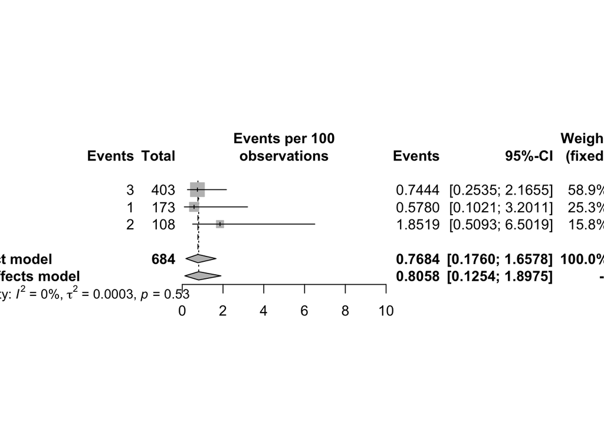

```r
precision=sqrt(ies.da.sj$vi)
pes.summary=metaprop(rupt, total_10, data=dat, sm="PFT", method.tau = "SJ", method.ci = "WS")
forest(pes.summary,
       pscale = 100,
       sortvar = precision,
       xlim=c(0,10),
       digits = 4)
```

This shows that the point estimate and confidence intervals are lower when the studies are larger. This might indicate publication bias, or instead a true difference in the effect size because of differences in the underlying populations included.

## Next carry out formal tests to identify outliers and influential studies

Screen studies by checking their externally studentized residuals (z-value) . Studentized residuals are more effective for detecting outliers than standardized residuals. If an observation has an externally studentized residual that is larger than 2 it may be an outlier, if it is larger than 3, it is an outlier.

```r
stud.res=rstudent(pes.da.sj)
abs.z=abs(stud.res$z)
stud.res[order(-abs.z)]
```

```
##
##     resid     se       z
## 2  0.0587 0.0523  1.1219
## 1 -0.0232 0.0487 -0.4765
## 3 -0.0187 0.0542 -0.3451
```

Once we have screened studies, include all potential outliers with z-values of 2 or more for leave-one-out analysis

```r
l1o = leave1out(pes.da.sj, transf=transf.ipft.hm, targ=list(ni=dat$total_10))
print(l1o, digits = 4)
```

```
##
##   estimate   zval   pval  ci.lb  ci.ub      Q     Qp   tau2      I2     H2
## 1   0.0108 3.3767 0.0007 0.0004 0.0307 0.9492 0.3299 0.0006 23.4014 1.3055
## 2   0.0059 4.4475 0.0000 0.0006 0.0150 0.0009 0.9767 0.0000  0.0000 1.0000
## 3   0.0095 3.7345 0.0002 0.0006 0.0254 1.1625 0.2810 0.0006 29.9378 1.4273
```

The summary estimate at line 1 is the summary proportion when the first study is removed, and the summary proportion recalculated.

This can be displayed as a forest plot as well for visual analysis.

yi = individual effect size ie individual proportion in this study vi = sampling variances

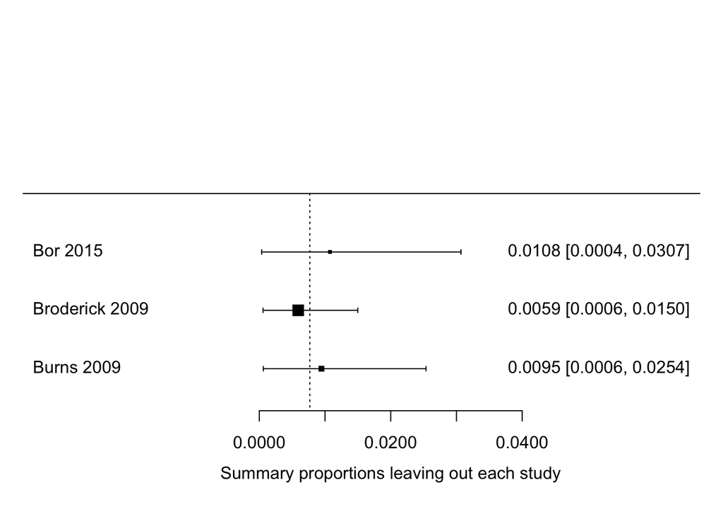

```r
l1o=leave1out(pes.da.sj)
yi=l1o$estimate; vi=l1o$se^2
forest(yi, vi, transf=transf.ipft.hm,
       targ=list(ni=dat$total_10),
       slab=paste(dat$authpub),
       refline=pes$pred,
       xlab="Summary proportions leaving out each study",
       digits = 4)
```

Verify this information with likely influential studies, using metafor testing.

```r
inf=influence(pes.da.sj)
print(inf)
```

```
##
##   rstudent  dffits cook.d  cov.r tau2.del QE.del    hat  weight    dfbs inf
## 1  -0.4765 -0.4983 0.3083 2.3467   0.0006 0.9492 0.5258 52.5827 -0.5118
## 2   1.1219  0.5317 0.2463 0.8586   0.0000 0.0009 0.1908 19.0839  0.5838
## 3  -0.3451 -0.2741 0.0872 1.7305   0.0006 1.1625 0.2833 28.3334 -0.2677
```

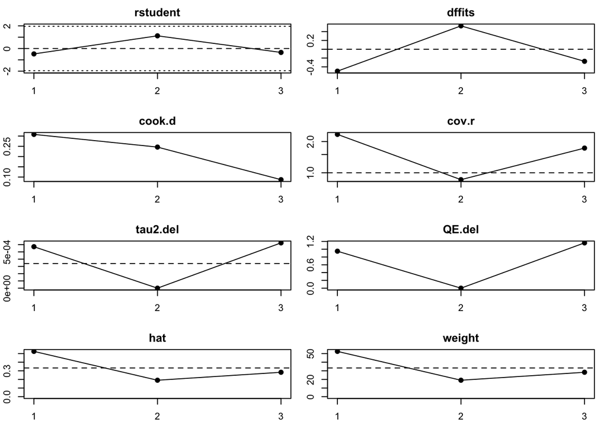

```r
plot(inf)
```

In this 3 study sample, no influential studies have been identified. tt

# Create sub-group proportions and perform moderator analysis

## Sub-group proportions

Firstly, we should assume that between-study variance may differ across the sub-groups. Thus we need to apply a mixed-effects model. First apply a random effects models to each subgroup, to allow the between-study variances to be different, and then fit a fixed effect model to combine studies within each sub-group to produce the summary effect size estimate.

Note that at least 5 studies each are required for each moderator in a multivariate meta-regression model. Thus to begin moderator analysis, you’ll need at least 10 studies. In our example, given the total of 15 studies in the 3 mm or less cohort, and 31 studies total, only 2 moderators were chosen which are aneurysm size at study entry and previous exposure to subarachnoid haemorrhage.